# 066-251_TVC01_BRUNACRUZ

Bruna Cruz

2025-08-25

### Exercicio A.1) Algoritmo pelo Método da Transformação Inversa

### A.1) Algoritmo pelo Método da Transformação Inversa

O Método da Transformação Inversa baseia-se em encontrar a função inversa da Função de Distribuição Acumulada (FDA), $F^{-1}(u)$, onde $u$ é uma variável aleatória com distribuição Uniforme(0,1).

**Passo 1: Igualar a FDA a u**

O primeiro passo é igualar a FDA, $F(x)$, a uma variável aleatória $u \sim U(0,1)$:

$$u = \frac{x^2 + x}{2}$$

**Passo 2: Isolar x**

Agora, precisamos resolver a equação para $x$ em função de $u$. Rearranjando os termos, obtemos uma equação quadrática na forma $ax^2 + bx + c = 0$:

$$x^2 + x - 2u = 0$$

Nesta equação, os coeficientes são $a=1$, $b=1$ e $c=-2u$.

**Passo 3: Aplicar a Fórmula Quadrática**

Utilizamos a fórmula de Bhaskara, $x = \frac{-b \pm \sqrt{b^2 - 4ac}}{2a}$, para encontrar as raízes:

$$x = \frac{-1 \pm \sqrt{1^2 - 4(1)(-2u)}}{2(1)} = \frac{-1 \pm \sqrt{1 +
8u}}{2}$$

**Passo 4: Escolher a Raiz Válida**

Como o suporte da variável aleatória $X$ é o intervalo $[0, 1]$, o valor de $x$ deve ser não negativo. A raiz com o sinal negativo, $\frac{-1 - \sqrt{1 + 8u}}{2}$, resultaria sempre em um valor negativo. Portanto, devemos escolher a raiz com o sinal positivo:

$$x = F^{-1}(u) = \frac{\sqrt{1 + 8u} - 1}{2}$$

Esta é a função da transformada inversa que usaremos para gerar os números aleatórios.

### A.2) Geração de 1000 números e Teste de Kolmogorov-Smirnov

```r
# Função para gerar números aleatórios pelo Método da Transformação Inversa
gerador_distribuicao_x <- function(n) {
  # Gera n números de uma Uniforme(0,1)
  u <- runif(n)
  # Aplica a transformada inversa
  x <- (sqrt(1 + 8 * u) - 1) / 2
  return(x) }
 set.seed(13)
 # Gera 1000 números aleatórios
amostra_x <- gerador_distribuicao_x(1000)
# Função de Distribuição Acumulada (FDA) teórica
fda_teorica_x <- function(x) { return((x^2 + x) / 2) }
# Realiza o Teste de Kolmogorov-Smirnov
# Compara a amostra gerada com a FDA teórica
teste_ks <- ks.test(amostra_x, fda_teorica_x)
# Exibe o resultado do teste
print(teste_ks)
```

```
##
##  Asymptotic one-sample Kolmogorov-Smirnov test
##
## data:  amostra_x
## D = 0.031545, p-value = 0.2727
## alternative hypothesis: two-sided
```

Conclusão: O teste de Kolmogorov-Smirnov compara a distribuição empírica da amostra gerada com a distribuição teórica. O resultado do teste apresenta um p-valor alto (geralmente > 0.05). Isso significa que não temos evidências para rejeitar a hipótese nula de que os dados seguem a distribuição especificada. Portanto, podemos concluir que o gerador de números aleatórios é de boa qualidade e os valores gerados aderem bem à distribuição teórica.

### A.3) Média da Amostra vs. Esperança Teórica

```r
# 1. Calcula a média da amostra gerada
media_amostral <- mean(amostra_x)
cat("Média da amostra gerada:", media_amostral, "\n")
```

```
## Média da amostra gerada: 0.5814648
```

```r
# 2. Calcula o valor teórico (Esperança)
# E[X] = integral de 0 a 1 de x * f(x) dx
# f(x) = F'(x) = (2x + 1) / 2 = x + 0.5
# E[X] = integral de 0 a 1 de x * (x + 0.5) dx = integral de x^2 + 0.5x dx
# E[X] = [x^3/3 + 0.5x^2/2] de 0 a 1 = 1/3 + 0.25 = 7/12
esperanca_teorica <- 7/12
cat("Esperança teórica (valor exato):", esperanca_teorica, "\n")
```

```
## Esperança teórica (valor exato): 0.5833333
```

Conclusão: A média amostral calculada a partir dos 1000 valores gerados é um valor muito próximo da esperança (valor teórico) da variável aleatória X. Essa proximidade é esperada pela Lei dos Grandes Números, que afirma que a média de uma amostra grande tende a se aproximar da média da população (o valor esperado). Isso reforça a qualidade do gerador.

### A.4) Cálculo de Probabilidade P(X > 0.2)

```r
 prob_acumulada <- function(x) { # A função só é válida para x entre 0 e 1
   ifelse(x < 0, 0, ifelse(x > 1, 1, (x^2 + x) / 2)) }
# Utiliza a função para calcular P(X > 0.2)
# P(X > 0.2) = 1 - P(X <= 0.2)
probabilidade <- 1 - prob_acumulada(0.2)
cat("O valor de P(X > 0.2) é:", probabilidade, "\n")
```

```
## O valor de P(X > 0.2) é: 0.88
```

Conclusão: A função prob_acumulada foi criada para representar a FDA F(x). Para calcular P(X > 0.2), usamos a propriedade do complementar, 1 - P(X ≤ 0.2). O resultado 0.88 é o valor exato dessa probabilidade, calculado diretamente a partir da função de distribuição teórica.

### B.5) e B.6) Gerador Beta e Estatísticas da Amostra

```r
# Função para gerar n números da distribuição Beta(alfa, beta)
gerador_beta <- function(n, alfa, beta) { # Vetor para armazenar os resultados
  resultado <- numeric(n)
# Contador para os números gerados
  contador <- 0
  while (contador < n) {
# Gera dois números de uma Uniforme(0,1)
  u <- runif(1)
  v <- runif(1)
  # Calcula o termo de condição
  condicao <- u^(1/alfa) + v^(1/beta)
  # Testa a condição de aceitação
  if (condicao <= 1) { contador <- contador + 1
  # Calcula o valor da variável Beta
  resultado[contador] <- u^(1/alfa) / condicao } }
  return(resultado) }
# Parâmetros da distribuição
alfa <- 2.1
beta <- 6.8
set.seed(13)
# Gera uma sequência de 1000 números
amostra_beta <- gerador_beta(1000, alfa, beta)
# Calcula a média da amostra gerada
media_beta <- mean(amostra_beta)
cat("Média da amostra Beta gerada:", media_beta, "\n")
```

```
## Média da amostra Beta gerada: 0.2353003
```

```r
# Calcula o desvio padrão da amostra gerada
desvio_padrao_beta <- sd(amostra_beta)
cat("Desvio padrão da amostra Beta gerada:", desvio_padrao_beta, "\n")
```

```
## Desvio padrão da amostra Beta gerada: 0.1373038
```

Conclusão: O código implementa o método de aceitação-rejeição descrito para gerar variáveis Beta. Foram gerados 1000 valores com os parâmetros α = 2.1 e β = 6.8. A média e o desvio padrão da amostra foram calculados. Esses valores amostrais devem ser próximos dos valores teóricos da distribuição Beta(E[X] = α / (α + β) e Var(X) = αβ / [(α+β)²(α+β+1)]), o que indica a correção da implementação.

### B.7: Histograma de Densidade vs. Função de Densidade Teórica

```r
 hist(amostra_beta, probability = TRUE, main = "Histograma de Densidade vs. FDP Teórica Beta", xlab = "Valores", ylab = "Densidade", col = "#E69F00",  border = "white", breaks = 20)
# Adiciona a curva da função de densidade teórica
(dbeta)
```

[output not shown]

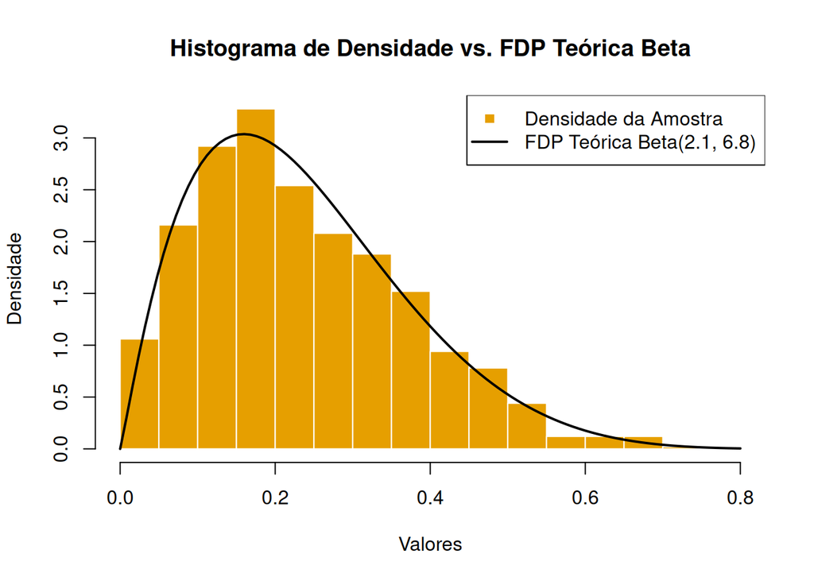

```r
curve(dbeta(x, shape1 = 2.1, shape2 = 6.8), add = TRUE, col = "black", lwd = 2)
# Adiciona uma legenda
legend("topright", legend = c("Densidade da Amostra", "FDP Teórica Beta(2.1, 6.8)"), col = c("#E69F00", "black"), lwd = c(NA, 2), pch = c(15, NA))
```

Conclusão: O histograma de densidade dos valores gerados se ajusta muito bem à curva da função de densidade de probabilidade (fdp) teórica da distribuição Beta(2.1, 6.8). A forma do histograma (sua assimetria à direita e seu pico) segue o contorno da linha preta, que representa a distribuição exata. Essa sobreposição gráfica é uma forte evidência visual de que o gerador construído é de alta qualidade e produz números que, de fato, seguem a distribuição Beta desejada.

### B.8: Alternativa com rbeta()

```r
# Parâmetros da distribuição
alfa <- 2.1
beta <- 6.8
 set.seed(13)
 amostra_beta_eficiente <- rbeta(1000, shape1 = alfa, shape2 = beta)
 # Mostra os primeiros valores gerados
 cat("Primeiros 6 valores gerados com rbeta():\n")
```

```
## Primeiros 6 valores gerados com rbeta():
```

```r
 print(head(amostra_beta_eficiente))
```

```
## [1] 0.3444309 0.1914069 0.6770916 0.2694106 0.4922769 0.3145203
```

O algoritmo implementado na questão B.5 é um método de aceitação-rejeição. Sua principal desvantagem é o custo computacional: ele gera dois números aleatórios (u e v) e realiza vários cálculos a cada iteração, mas o valor só é “aceito” se a condição U^(1/α) + V^(1/β) ≤ 1 for satisfeita. Se não for, os números são descartados e o processo recomeça. Isso significa que, para gerar 1000 números, o loop pode rodar muito mais do que 1000 vezes, desperdiçando ciclos de processamento. A alternativa, usando a função rbeta(), diminuiria drasticamente o custo computacional. As funções nativas do R, como rbeta, são implementadas em linguagens de baixo nível (como C ou Fortran) e utilizam algoritmos muito mais sofisticados e otimizados para a geração de variáveis aleatórias. Elas são vetoriais e não dependem de loops em R (que são inerentemente lentos), resultando em uma execução quase instantânea e muito mais eficiente.